# Practical Lab 3 - Univariate Linear Regression

### Topic : Univariate Linear Regression on the California Housing Prices Dataset

### Goal :

The goal is to see how median house value relates to median income, population, and number of households. Three separate tests are run to find out which factor has the most impact on house prices.

Here is the link of data sets from [kaggle - California Housing Prices](https://www.kaggle.com/datasets/camnugent/california-housing-prices)

```python
from sklearn import linear_model
import numpy as np
import pandas as pd
import matplotlib.pyplot as plt
import seaborn as sns
from sklearn.metrics import mean_absolute_error
```

```python
df_house = pd.read_csv("./data/housing.csv")
df_house.describe()
```

|  | longitude | latitude | housing_median_age | total_rooms | total_bedrooms | population | households | median_income | median_house_value |
| --- | --- | --- | --- | --- | --- | --- | --- | --- | --- |
| count | 20640.000000 | 20640.000000 | 20640.000000 | 20640.000000 | 20433.000000 | 20640.000000 | 20640.000000 | 20640.000000 | 20640.000000 |
| mean | -119.569704 | 35.631861 | 28.639486 | 2635.763081 | 537.870553 | 1425.476744 | 499.539680 | 3.870671 | 206855.816909 |
| std | 2.003532 | 2.135952 | 12.585558 | 2181.615252 | 421.385070 | 1132.462122 | 382.329753 | 1.899822 | 115395.615874 |
| min | -124.350000 | 32.540000 | 1.000000 | 2.000000 | 1.000000 | 3.000000 | 1.000000 | 0.499900 | 14999.000000 |
| 25% | -121.800000 | 33.930000 | 18.000000 | 1447.750000 | 296.000000 | 787.000000 | 280.000000 | 2.563400 | 119600.000000 |
| 50% | -118.490000 | 34.260000 | 29.000000 | 2127.000000 | 435.000000 | 1166.000000 | 409.000000 | 3.534800 | 179700.000000 |
| 75% | -118.010000 | 37.710000 | 37.000000 | 3148.000000 | 647.000000 | 1725.000000 | 605.000000 | 4.743250 | 264725.000000 |
| max | -114.310000 | 41.950000 | 52.000000 | 39320.000000 | 6445.000000 | 35682.000000 | 6082.000000 | 15.000100 | 500001.000000 |

Longitude, latitude, housing_median_age, total_rooms, total_bedrooms, population, households, median_income, and median_house_value are the variables contained within this dataset.

The data-derived df_house.description() summarises the dataset's primary tendencies and distribution, providing more light on its features related to housing.

Data variables range and Issue noticed in data :

1. population = There is a huge variation in the number of people living in California which is from 3 to 35682.
2. households = Houses are in range of 1 to 6082 which shows a variation in population.
3. median_income = 0.499900 to 15 and these values are not standardised making it difficult to analysis.
4. median_house_value = $14,999 to $500,001 and having outliers in this range and may impact the output.

# Graph 1 Median income vs Median house value

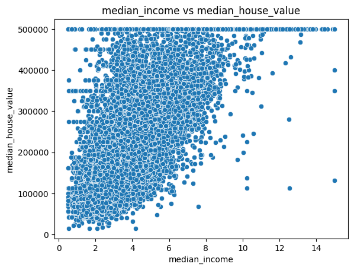

```python
sns.scatterplot(x='median_income' , y= 'median_house_value', data=df_house)
plt.title('median_income vs median_house_value')
```

Graph Analysis:The seaborn-generated graph indicates a clustering of houses falling within a median income range of 2 to 8 and a median house value range of 100,000 to 400,000. This clustering suggests that applying a linear regression model could be appropriate for analysis.

# Graph 2 Median House Value and Households

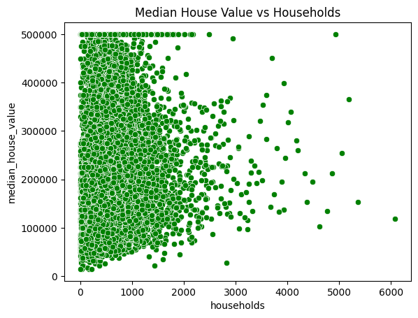

```python
sns.scatterplot(x='households' , y= 'median_house_value', data=df_house, color ='green')
plt.title('Median House Value vs Households')
```

Graph Analysis:The seaborn-generated graph indicates a clustering of houses falling within a median house value range of 100000 to 400000 and households are in range between 1 to 2000 This clustering suggests that applying a linear regression model could be appropriate for analysis.

# Graph 3 Median House Value and Population

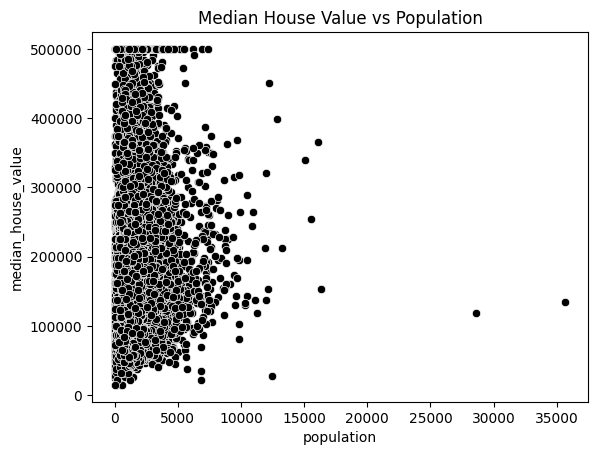

```python
sns.scatterplot(x='population' , y= 'median_house_value', data=df_house , color = 'black')
plt.title('Median House Value vs Population')
```

Graph Analysis:The seaborn-generated graph indicates a clustering of houses falling within a median house value range of 100000 to 400000 and households are in range between 3 to 10000 This clustering suggests that applying a linear regression model could be appropriate for analysis.

# Linear regression For Graph 1, Intercept and coefficients

```python
median_income_model =linear_model.LinearRegression()
median_income_model.fit(X=df_house[['median_income']], y=df_house[['median_house_value']])

print(f"Intercept: {median_income_model.intercept_}")
print(f"Coefficients: {median_income_model.coef_}")
```

```
Intercept: [45085.57670327]
Coefficients: [[41793.8492019]]
```

# Linear regression For Graph 2, Intercept and coefficients

```python
households_model =linear_model.LinearRegression()
households_model.fit(X=df_house[['households']], y=df_house[['median_house_value']])

print(f"Intercept: {households_model.intercept_}")
print(f"Coefficients: {households_model.coef_}")
```

```
Intercept: [196928.57716233]
Coefficients: [[19.87277516]]
```

# Linear regression For Graph 3, Intercept and coefficients

```python
population_model =linear_model.LinearRegression()
population_model.fit(X=df_house[['population']], y=df_house[['median_house_value']])

print(f"Intercept: {population_model.intercept_}")
print(f"Coefficients: {population_model.coef_}")
```

```
Intercept: [210436.26207627]
Coefficients: [[-2.51175277]]
```

# Intercept and slope

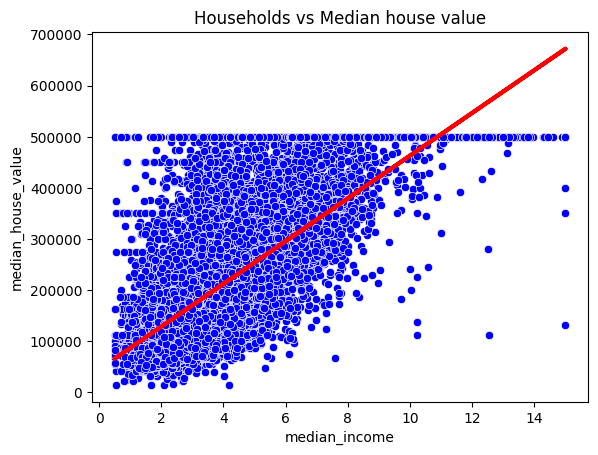

```
Mean squared error: 7011311502.929527
Mean absolute error: 62625.9337911434
```

```python
from sklearn.metrics import mean_absolute_error, mean_squared_error
plt.title('Households vs Median house value')

# plot the regression line against the training data
sns.scatterplot(x="median_income", y="median_house_value", data=df_house, color="blue")
plt.plot(df_house[["median_income"]], median_income_model.predict(df_house[["median_income"]]), color="red", linewidth=3)
plt.show()

print(f"Mean squared error: {mean_squared_error(df_house[['median_house_value']], median_income_model.predict(df_house[['median_income']]))}")
print(f"Mean absolute error: {mean_absolute_error(df_house[['median_house_value']], median_income_model.predict(df_house[['median_income']]))}")
```

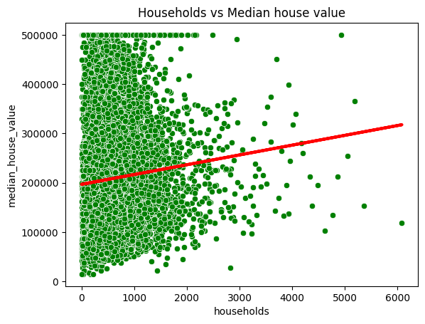

```
Mean squared error: 13257776904.728533
Mean absolute error: 90802.74324318448
```

```python
from sklearn.metrics import mean_absolute_error, mean_squared_error
plt.title('Households vs Median house value')

# plot the regression line against the training data
sns.scatterplot(x="households", y="median_house_value", data=df_house, color="Green")
plt.plot(df_house[["households"]], households_model.predict(df_house[["households"]]), color="red", linewidth=3)
plt.show()

print(f"Mean squared error: {mean_squared_error(df_house[['median_house_value']], households_model.predict(df_house[['households']]))}")
print(f"Mean absolute error: {mean_absolute_error(df_house[['median_house_value']], households_model.predict(df_house[['households']]))}")
```

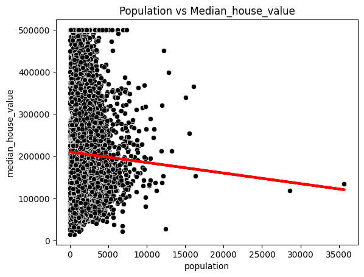

```
Mean squared error: 13307412412.389355
Mean absolute error: 91153.82009473183
```

```python
from sklearn.metrics import mean_absolute_error, mean_squared_error
plt.title('Population vs Median_house_value')

# plot the regression line against the training data
sns.scatterplot(x="population", y="median_house_value", data=df_house, color="black")
plt.plot(df_house[["population"]], population_model.predict(df_house[["population"]]), color="red", linewidth=3)
plt.show()

print(f"Mean squared error: {mean_squared_error(df_house[['median_house_value']], population_model.predict(df_house[['population']]))}")
print(f"Mean absolute error: {mean_absolute_error(df_house[['median_house_value']], population_model.predict(df_house[['population']]))}")
```

# Summarizing in a table, for each of the three models :

#### Summary

| Model | Intercept | Slope | Mean Squared Error | Mean Absolute Error |
| --- | --- | --- | --- | --- |
| Median_Income | 45085.57670327 | 41793.8492019 | 7011311502.929527 | 62625.9337911434 |
| Households | 196928.57716233 | 19.87277516 | 13257776904.728533 | 90802.74324318448 |
| Population | 210436.26207627 | -2.51175277 | 13307412412.389355 | 91153.82009473183 |

# Conclusion :

The model based on median income performs the best, with the lowest error rates, indicating it's most accurate. On the other hand, the households model has higher errors, suggesting it's not as precise. Similarly, the population model also shows higher errors, meaning it might not predict as accurately.

Overall, each model has its own set of strengths and weaknesses in terms of accuracy and error rates